# Final Project Sleep Effciency

Yilin Zhang

2025-02-21

# Introduction

This project will use the “Sleep_Efficiency.csv” dataset. This dataset contains multiple indicators related to sleep quality, sleep duration, sleep depth, and lifestyle habits (such as caffeine intake, smoking, exercise frequency, etc.). It aims to explore the possible relationship between different variables (such as caffeine intake, alcohol intake, exercise frequency, etc.) and sleep efficiency; build regression models and compare their prediction errors to evaluate the impact of these variables on sleep efficiency; and use tables and visualizations to better understand the data.

## Load the Data

```r
sleep_data <- read_csv("C:/Users/Lenovo/Desktop/data550/final/Sleep_Efficiency.csv", show_col_types = FALSE)
colnames(sleep_data) <- c("ID","age","gender","bedtime","wakeup_time","sleep_duration","sleep_efficiency","rem_sleep_percentage","deep_sleep_percentage","light_sleep_percentage","awakenings","caffeine_consumption","alchol_consumption","smoking_status","exercise_frequency")
summary(sleep_data)
```

```
##        ID             age           gender
##  Min.   :  1.0   Min.   : 9.00   Length:452
##  1st Qu.:113.8   1st Qu.:29.00   Class :character
##  Median :226.5   Median :40.00   Mode  :character
##  Mean   :226.5   Mean   :40.29
##  3rd Qu.:339.2   3rd Qu.:52.00
##  Max.   :452.0   Max.   :69.00
##
##     bedtime                        wakeup_time
##  Min.   :2021-01-03 00:30:00.00   Min.   :2021-01-03 08:30:00.00
##  1st Qu.:2021-04-14 01:07:30.00   1st Qu.:2021-04-14 07:52:30.00
##  Median :2021-07-20 23:30:00.00   Median :2021-07-20 16:00:00.00
##  Mean   :2021-07-13 00:03:39.02   Mean   :2021-07-12 20:19:22.82
##  3rd Qu.:2021-10-11 05:22:30.00   3rd Qu.:2021-10-11 05:52:30.00
##  Max.   :2021-12-31 21:00:00.00   Max.   :2021-12-31 06:30:00.00
##
##  sleep_duration   sleep_efficiency rem_sleep_percentage deep_sleep_percentage
##  Min.   : 5.000   Min.   :0.5000   Min.   :15.00        Min.   :18.00
##  1st Qu.: 7.000   1st Qu.:0.6975   1st Qu.:20.00        1st Qu.:48.25
##  Median : 7.500   Median :0.8200   Median :22.00        Median :58.00
##  Mean   : 7.466   Mean   :0.7889   Mean   :22.62        Mean   :52.82
##  3rd Qu.: 8.000   3rd Qu.:0.9000   3rd Qu.:25.00        3rd Qu.:63.00
##  Max.   :10.000   Max.   :0.9900   Max.   :30.00        Max.   :75.00
##
##  light_sleep_percentage   awakenings    caffeine_consumption alchol_consumption
##  Min.   : 7.00          Min.   :0.000   Min.   :  0.00       Min.   :0.000
##  1st Qu.:15.00          1st Qu.:1.000   1st Qu.:  0.00       1st Qu.:0.000
##  Median :18.00          Median :1.000   Median : 25.00       Median :0.000
##  Mean   :24.56          Mean   :1.641   Mean   : 23.65       Mean   :1.174
##  3rd Qu.:32.50          3rd Qu.:3.000   3rd Qu.: 50.00       3rd Qu.:2.000
##  Max.   :63.00          Max.   :4.000   Max.   :200.00       Max.   :5.000
##                         NA's   :20      NA's   :25           NA's   :14
##  smoking_status     exercise_frequency
##  Length:452         Min.   :0.000
##  Class :character   1st Qu.:0.000
##  Mode  :character   Median :2.000
##                     Mean   :1.791
##                     3rd Qu.:3.000
##                     Max.   :5.000
##                     NA's   :6
```

## Clean the data

```r
summary(is.na(sleep_data))
```

```
##      ID             age            gender         bedtime
##  Mode :logical   Mode :logical   Mode :logical   Mode :logical
##  FALSE:452       FALSE:452       FALSE:452       FALSE:452
##
##  wakeup_time     sleep_duration  sleep_efficiency rem_sleep_percentage
##  Mode :logical   Mode :logical   Mode :logical    Mode :logical
##  FALSE:452       FALSE:452       FALSE:452        FALSE:452
##
##  deep_sleep_percentage light_sleep_percentage awakenings
##  Mode :logical         Mode :logical          Mode :logical
##  FALSE:452             FALSE:452              FALSE:432
##                                               TRUE :20
##  caffeine_consumption alchol_consumption smoking_status  exercise_frequency
##  Mode :logical        Mode :logical      Mode :logical   Mode :logical
##  FALSE:427            FALSE:438          FALSE:452       FALSE:446
##  TRUE :25             TRUE :14                           TRUE :6
```

```r
sleep1 <- sleep_data %>%
  na.omit()
str(sleep1)
```

```
## tibble [388 × 15] (S3: tbl_df/tbl/data.frame)
##  $ ID                    : num [1:388] 1 2 3 4 5 7 8 9 10 11 ...
##  $ age                   : num [1:388] 65 69 40 40 57 27 53 41 11 50 ...
##  $ gender                : chr [1:388] "Female" "Male" "Female" "Female" ...
##  $ bedtime               : POSIXct[1:388], format: "2021-03-06 01:00:00" "2021-12-05 02:00:00" ...
##  $ wakeup_time           : POSIXct[1:388], format: "2021-03-06 07:00:00" "2021-12-05 09:00:00" ...
##  $ sleep_duration        : num [1:388] 6 7 8 6 8 6 10 6 9 8 ...
##  $ sleep_efficiency      : num [1:388] 0.88 0.66 0.89 0.51 0.76 0.54 0.9 0.79 0.55 0.92 ...
##  $ rem_sleep_percentage  : num [1:388] 18 19 20 23 27 28 28 28 18 23 ...
##  $ deep_sleep_percentage : num [1:388] 70 28 70 25 55 25 52 55 37 57 ...
##  $ light_sleep_percentage: num [1:388] 12 53 10 52 18 47 20 17 45 20 ...
##  $ awakenings            : num [1:388] 0 3 1 3 3 2 0 3 4 1 ...
##  $ caffeine_consumption  : num [1:388] 0 0 0 50 0 50 50 50 0 50 ...
##  $ alchol_consumption    : num [1:388] 0 3 0 5 3 0 0 0 0 0 ...
##  $ smoking_status        : chr [1:388] "Yes" "Yes" "No" "Yes" ...
##  $ exercise_frequency    : num [1:388] 3 3 3 1 3 1 3 1 0 3 ...
##  - attr(*, "na.action")= 'omit' Named int [1:64] 6 20 21 25 27 34 38 58 61 63 ...
##   ..- attr(*, "names")= chr [1:64] "6" "20" "21" "25" ...
```

# Table 1: Descriptive Statistics

```r
desc_stats <- sleep1 %>%
  summarise(
    Avg_Age = mean(age),
    Min_Age = min(age),
    Max_Age = max(age),
    Avg_SleepDuration = mean(sleep_duration),
    Avg_SleepEfficiency = mean(sleep_efficiency),
    Avg_DeepSleepPct = mean(deep_sleep_percentage),
    Avg_REM_SleepPct = mean(rem_sleep_percentage),
    Avg_Awakenings = mean(awakenings)
  )

kable(desc_stats, caption = "Table 1. Selected Descriptive Statistics of the Sleep Data")
```

Table 1. Selected Descriptive Statistics of the Sleep Data

| Avg_Age | Min_Age | Max_Age | Avg_SleepDuration | Avg_SleepEfficiency | Avg_DeepSleepPct | Avg_REM_SleepPct | Avg_Awakenings |
| --- | --- | --- | --- | --- | --- | --- | --- |
| 40.8299 | 9 | 69 | 7.451031 | 0.7892526 | 52.82216 | 22.68041 | 1.618557 |

From Table 1, we can see that the average age of the subjects in this dataset is about 40.8 years old, the average sleep duration is about 7.45 hours, the average sleep efficiency is 0.789, the average deep sleep percentage and the average REM sleep percentage are 52.82% and 22.68% respectively.

# EDA

## Correlation between all the variables

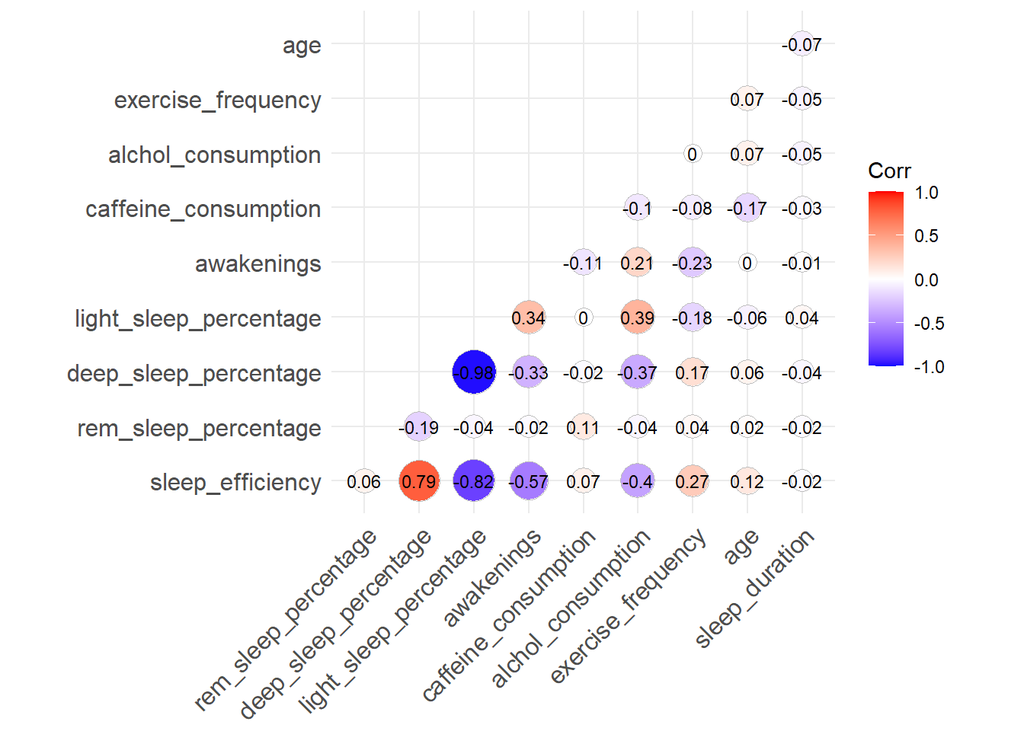

```r
cor_data <- sleep1 %>%
  select(sleep_efficiency, rem_sleep_percentage, deep_sleep_percentage,
         light_sleep_percentage, awakenings, caffeine_consumption,
         alchol_consumption, smoking_status, exercise_frequency, age,
         sleep_duration)

#Calculate the correlation coefficient
corr_matrix <- cor(
  dplyr::select_if(cor_data, is.numeric),
  use="complete.obs"
)

# plot
ggcorrplot::ggcorrplot(corr_matrix,
                       method="circle",
                       type="lower",
                       lab=TRUE, lab_size=3)
```

## Correlation between factors related to sleep efficiency

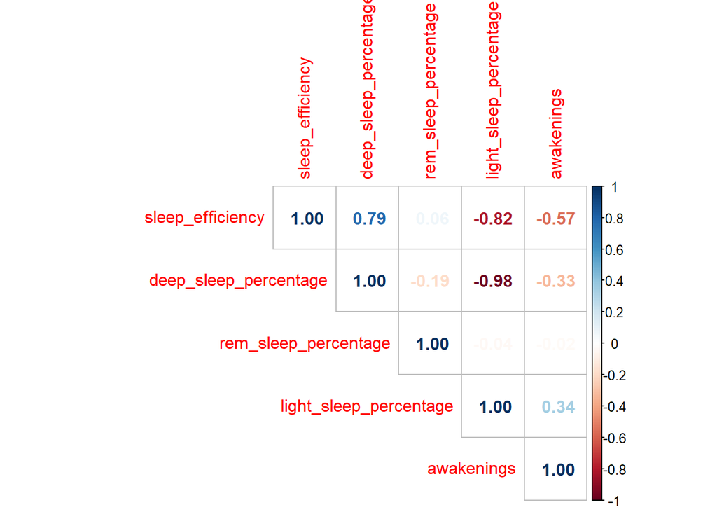

```r
sleep1 %>%
  select(sleep_efficiency, deep_sleep_percentage, rem_sleep_percentage,
         light_sleep_percentage, awakenings) %>%
  cor() %>%
  corrplot(method = "number", type = "upper")
```

Sleep efficiency and deep sleep percentage show a strong positive correlation (about 0.79). In other words, the higher the proportion of deep sleep, the higher the sleep efficiency. Sleep efficiency and awakenings show a significant negative correlation (about -0.57). This means that if there are more awakenings during the night, the overall sleep efficiency tends to decrease. Deep sleep percentage and light sleep percentage show a significant negative correlation (about -0.98). This reflects the relationship between deep sleep and light sleep in a total sleep time: when deep sleep increases, light sleep will naturally decrease. The correlation between REM sleep percentage and sleep efficiency is not high (around 0 ~ 0.1), indicating that the impact of REM sleep percentage on overall sleep efficiency may be weak or not linear.

# Figures Demonstrating Relationships

## Caffeine Consumption vs. Sleep Efficiency

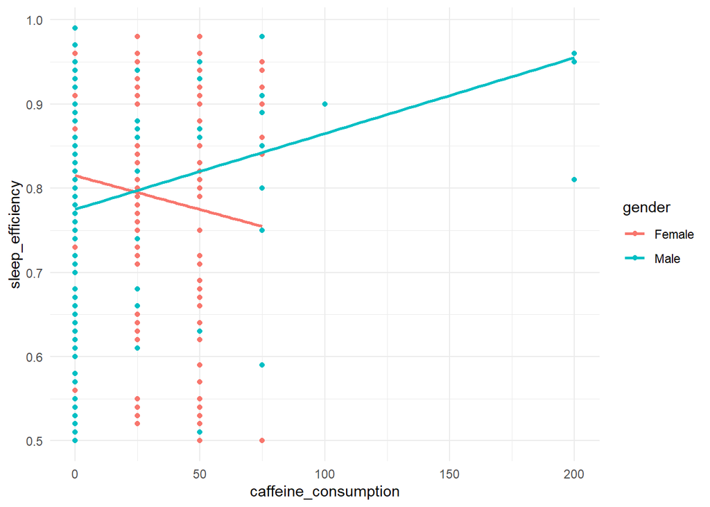

```r
sleep1 %>%
  ggplot(aes(x = caffeine_consumption, y = sleep_efficiency, color = gender)) +
  geom_point() +
  geom_smooth(method = "lm", se = FALSE, aes(group = gender)) +
  theme_minimal()
```

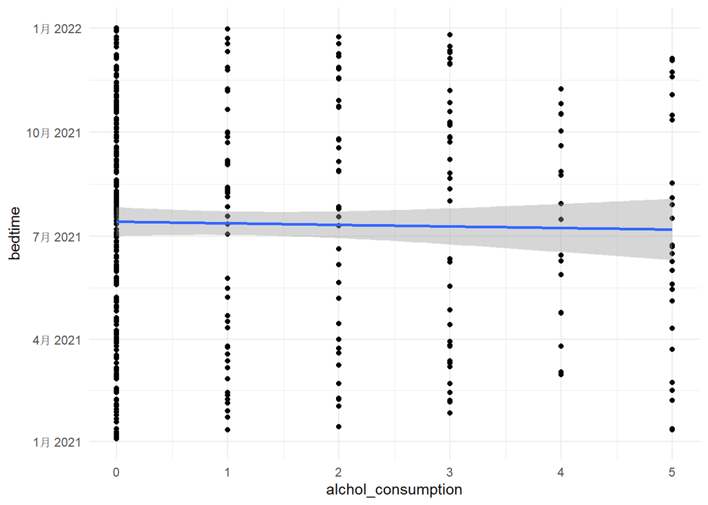

```r
ggplot(data=sleep1, aes(x = alchol_consumption, y=bedtime))+
  geom_point() +
  stat_smooth(method="lm", se=TRUE) +
  theme_minimal()
```

The regression line is relatively flat, indicating that the linear relationship between different alcohol intakes and bedtimes in this data set is not obvious, or that “how much alcohol you drink” does not seem to make people go to bed earlier or later.